# MixSIAR model

2026-03-02

## Introduction

For a more explainable model than the initial Dirichlet process model, I will attempt to use the `MixSIAR` package to create a mixture model.

## Import data

First we will import the pot data:

```r
ds <- read.csv(paste0(DATA_DIR, 'sustainlipids.csv'), header = TRUE)
balk <-  subset(ds, grouping == "Balkans")
groups <- split(balk$D13C, balk$bin)
head(balk)
```

```
##   X Sample.ID    d13C16    d13C18       D13C sitecode    sitename    lat   long
## 1 1  MOIII005 -26.67109 -25.85030  0.8207955     MIKR Mikri Volvi 40.745 22.978
## 2 1  MOIII009 -28.53581 -29.15502 -0.6192163     MIKR Mikri Volvi 40.745 22.978
## 3 1  MOIII022 -27.07577 -28.64161 -1.5658330     MIKR Mikri Volvi 40.745 22.978
## 4 1      MV-1 -26.20000 -27.40000 -1.2000000     MIKR Mikri Volvi 40.745 22.978
## 5 1     MV-12 -26.40000 -26.70000 -0.3000000     MIKR Mikri Volvi 40.745 22.978
## 6 1     MV-32 -25.50000 -26.40000 -0.9000000     MIKR Mikri Volvi 40.745 22.978
##   country  group group_order bin grouping grouping_order culture vessel
## 1  Greece Greece               a  Balkans              a      EN
## 2  Greece Greece               a  Balkans              a      EN
## 3  Greece Greece               a  Balkans              a      EN
## 4  Greece Greece               a  Balkans              a      EN
## 5  Greece Greece               a  Balkans              a      EN
## 6  Greece Greece               a  Balkans              a      EN
##   aquatic_res      source
## 1           b whel2018a\n
## 2           b whel2018a\n
## 3           b whel2018a\n
## 4           b whel2018a\n
## 5           b whel2018a\n
## 6           b whel2018a\n
```

Next, we will import the reference fat data. I have two possibilities for this. `reference_fats1.csv` is the file of reference data you sent me. I created an initial column in the data that has the fat types `adipose_ruminant`, `adipose_nonruminant`, `dairy`, `freshwater_fish`, `freshwater_gastropod`, `freshwater_mollusc`, and `migratory_fish`.

I also created `reference_fats2.csv` based on the supplement of the paper you shared. The second reference fat data is in the mean / SD format and includes dairy, nonruminant fat, ruminant fat, and marine fat.

```r
# Load reference source data
ref_sources1 <- read.csv(paste0(DATA_DIR, 'reference_fats1.csv'), header = TRUE)
head(ref_sources1)
```

```
##                  X    original_type       ref correction fatType Species
## 1 adipose_ruminant adipose_ruminant Dudd 1999       corr Adipose     Cow
## 2 adipose_ruminant adipose_ruminant Dudd 1999       corr Adipose     Cow
## 3 adipose_ruminant adipose_ruminant Dudd 1999       corr Adipose     Cow
## 4 adipose_ruminant adipose_ruminant Dudd 1999       corr Adipose     Cow
## 5 adipose_ruminant adipose_ruminant Dudd 1999       corr Adipose   Sheep
## 6 adipose_ruminant adipose_ruminant Dudd 1999       corr Adipose   Sheep
##   Provenance          sampleID d13C16 d13C18 D13C C16Percent C18Percent
## 1    Britain              C1BB  -29.3  -32.2 -2.9       28.9       21.5
## 2    Britain              C1BK  -29.1  -31.9 -2.8       28.8       30.7
## 3    Britain              C1BR  -30.2  -32.7 -2.5       26.1       12.5
## 4    Britain              C2BB  -30.3  -32.0 -1.7       27.3       16.1
## 5    Britain E8B91 (ewe orig.)  -28.6  -30.4 -1.8       20.8       32.9
## 6    Britain    Hebridean lamb  -28.8  -31.7 -2.9       25.1       21.9
```

```r
unique(ref_sources1$X) # types of fat in ref_sources1
```

```
## [1] "adipose_ruminant"     "dairy"                "freshwater_fish"
## [4] "freshwater_gastropod" "freshwater_mollusc"   "migratory_fish"
## [7] "adipose_nonruminant"
```

```r
ref_sources2 <- read.csv(paste0(DATA_DIR, 'reference_fats2.csv'), header = TRUE)
head(ref_sources2)
```

```
##                  X Meand13C16 SDd13C16 Meand13C18 SDd13C18   n
## 1  porcine_adipose      -25.2      0.8      -24.4      0.9  66
## 2 ruminant_adipose      -29.1      1.3      -30.7      1.9  32
## 3   ruminant_dairy      -28.7      1.7      -33.6      2.4  36
## 4      marine_oils      -22.8      2.6      -22.3      2.6 100
```

```r
unique(ref_sources2$X) # types of fat in ref_sources2
```

```
## [1] "porcine_adipose"  "ruminant_adipose" "ruminant_dairy"   "marine_oils"
```

## Exploratory visualisation

We can look at a basic boxplot of $\Delta^{13}C$ for the different regions:

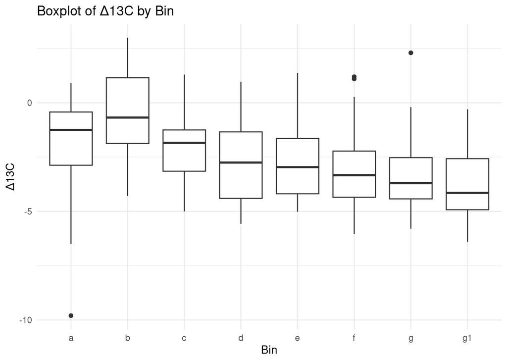

```r
# Boxplot of Δ13C by bin
# Does in fact seem like Δ13C decreases as we move north for the most part
ggplot(balk, aes(x = bin, y = D13C)) +
  geom_boxplot() +
  labs(title = "Boxplot of Δ13C by Bin", x = "Bin", y = "Δ13C") +
  theme_minimal()
```

We do seem to see the expected trend of $\Delta^{13}C$ decreasing from south to north.

## `MixSIAR` model

### Creating the model

In this type of model, we treat each pot as a weighted sum of different food sources, each of which has a different mean. The weights for each pot are drawn from a Dirichlet distribution, which can differ by region (bin). I ran the model using the reference data you sent me.

```r
# Load the mixture data
mix <- load_mix_data(
  filename = paste0(DATA_DIR, 'balk.csv'),
  iso_names = c("d13C16", "d13C18"),
  factors = "bin",
  fac_random = TRUE, # including a random effect for region
  fac_nested = FALSE, # we don't have a nested structure in this case
  cont_effects = NULL # column headings of continuous effects -- N/A in this case
)

# Load the source data
# Reference data shared by Isabel
source <- load_source_data(
  filename = paste0(DATA_DIR, 'reference_fats1.csv'),
  source_factors = NULL,
  conc_dep = FALSE, # do not have concentration dependence
  data_type = "raw",
  mix = mix
)

# Load the discrimination data
# we aren't looking at tissue of a consumer, so we just set TDF to 0
# Made a discrimination file following this format:
# https://github.com/brianstock/MixSIAR/blob/master/inst/extdata/wolves_discrimination.csv
discr <- load_discr_data(
  filename = paste0(DATA_DIR, 'discrimination1.csv'),
  mix = mix
)
```

We can visualise the isospace plot:

```
## `height` was translated to `width`.
## `height` was translated to `width`.
## `height` was translated to `width`.
## `height` was translated to `width`.
## `height` was translated to `width`.
```

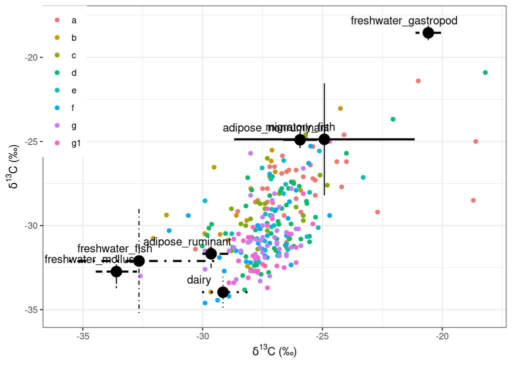

```r
# Make an isospace plot
plot_data(filename = paste0(PLOT_DIR, 'isospace_plot.png'),
          plot_save_pdf = FALSE,
          plot_save_png = TRUE,
          mix,
          source,
          discr,
          return_obj = TRUE)
```

We set an uninformative prior for the model, assuming that all fat sources are equally likely.

```r
# Write the JAGS model file
model_filename <- paste0(MODEL_DIR, "MixSIAR_model.txt")   # Name of the JAGS model file
resid_err <- TRUE
process_err <- TRUE
write_JAGS_model(model_filename, resid_err, process_err, mix, source)
```

Finally, we can run the model, starting with a test run. You can see all the pre-set MCMC run options here: https://brianstock.github.io/MixSIAR/articles/wolves_ex.html.

```r
# Run the model
# test run to check if the model is working as expected
jags.test <- run_model(run = "test", mix, source, discr, model_filename)
```

```
## module glm loaded
```

```
##    Declaring variables
##
```

```r
output_options <- list(summary_save = TRUE,
                       summary_name = paste0(MODEL_DIR, "summary_statistics"),
                       sup_post = FALSE,
                       plot_post_save_pdf = TRUE,
                       plot_post_name = paste0(PLOT_DIR, "posterior_density"),
                       sup_pairs = FALSE,
                       plot_pairs_save_pdf = TRUE,
                       plot_pairs_name = paste0(PLOT_DIR, "pairs_plot"),
                       sup_xy = TRUE,
                       plot_xy_save_pdf = FALSE,
                       plot_xy_name = paste0(PLOT_DIR, "xy_plot"),
                       gelman = TRUE,
                       heidel = FALSE,
                       geweke = TRUE,
                       diag_save = TRUE,
                       diag_name = paste0(MODEL_DIR, "diagnostics"),
                       indiv_effect = FALSE,
                       plot_post_save_png = FALSE,
                       plot_pairs_save_png = FALSE,
                       plot_xy_save_png = FALSE,
                       diag_save_ggmcmc = FALSE)

# output_JAGS(jags.test, mix, source, output_options)
```

### Interpreting the model

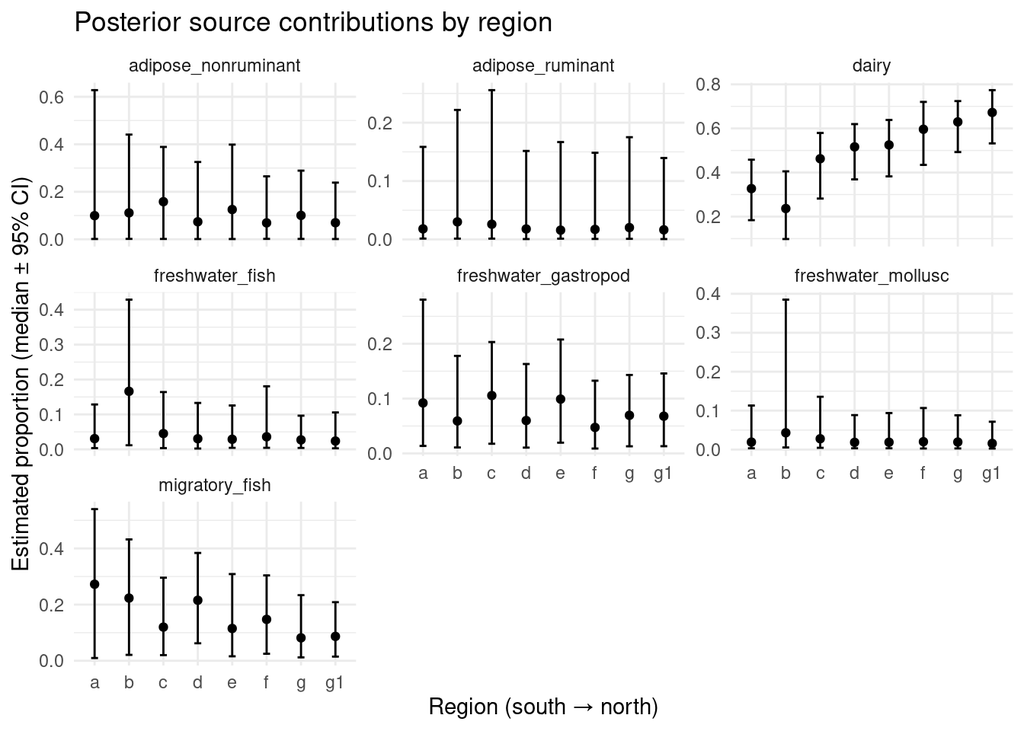

```r
post_array <- jags.test$BUGSoutput$sims.list$p.fac1
bin_names    <- unique(balk$bin)
source_names <- source$source_names

n_iter <- dim(post_array)[1]

# Build tidy dataframe
posterior_df <- expand.grid(
  iter = 1:n_iter,
  bin = bin_names,
  source = source_names
)

posterior_df$prop <- as.vector(post_array)

summary_df <- posterior_df %>%
  group_by(bin, source) %>%
  summarise(
    median = median(prop),
    lower  = quantile(prop, 0.025),
    upper  = quantile(prop, 0.975),
    .groups = "drop"
  )

# Plot the credible intervals for each source contribution by bin
ggplot(summary_df, aes(x = bin, y = median)) +
  geom_point() +
  geom_errorbar(aes(ymin = lower, ymax = upper), width = 0.2) +
  facet_wrap(~ source, scales = "free_y") +
  theme_minimal() +
  labs(
    title = "Posterior source contributions by region",
    x = "Region (south → north)",
    y = "Estimated proportion (median ± 95% CI)"
  )
```

I will demonstrate how we could compare the contribution of dairy between two regions:

```r
# Extract posterior samples for dairy contribution in regions a and g1
dairy_a <- post_array[, which(bin_names == "a"), which(source_names == "dairy")]
dairy_g1 <- post_array[, which(bin_names == "g1"), which(source_names == "dairy")]
# Calculate the difference in dairy contribution between regions a and g1
dairy_diff <- dairy_g1 - dairy_a
# Summarise the difference
dairy_diff_summary <- data.frame(
  median = median(dairy_diff),
  lower = quantile(dairy_diff, 0.025),
  upper = quantile(dairy_diff, 0.975)
)
dairy_diff_summary
```

```
##         median     lower     upper
## 2.5% 0.3394477 0.1812038 0.5163814
```

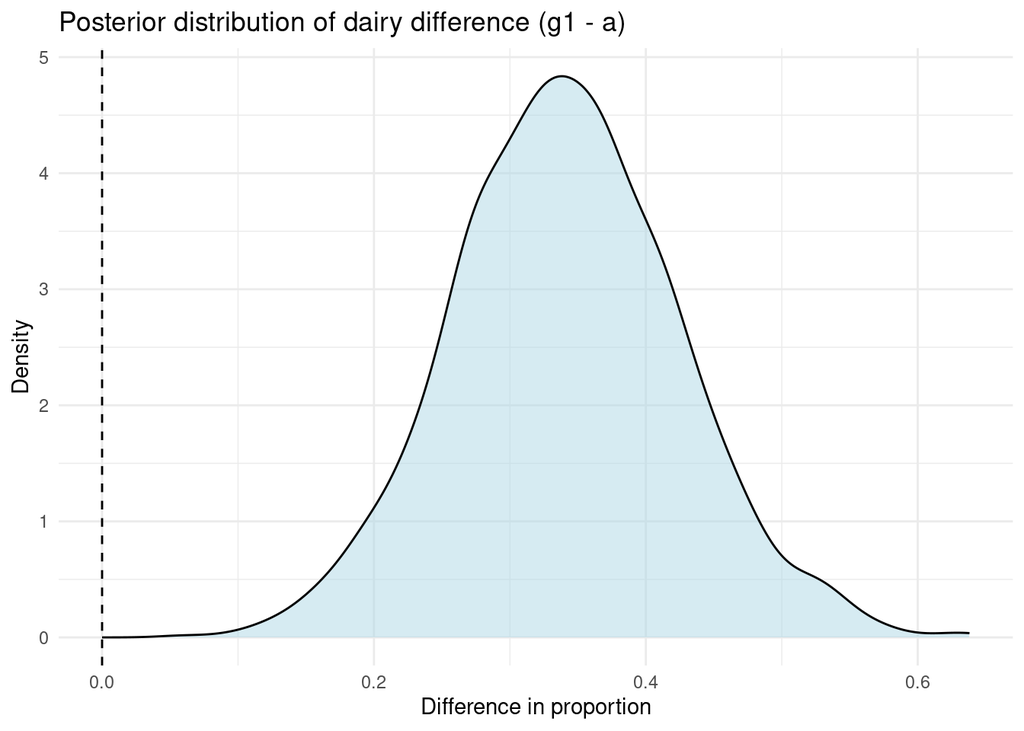

```r
# Visualise the difference:
ggplot(data.frame(diff = dairy_diff), aes(x = diff)) +
  geom_density(fill = "lightblue", alpha = 0.5) +
  geom_vline(xintercept = 0, linetype = "dashed") +
  labs(
    title = "Posterior distribution of dairy difference (g1 - a)",
    x = "Difference in proportion",
    y = "Density"
  ) +
  theme_minimal()
```

```r
# Posterior probability that dairy is more prevalent in region g1 than a
prob_g1_greater <- mean(dairy_diff > 0)
prob_g1_greater
```

```
## [1] 1
```

The median difference in dairy (0.3394477) contribution tells us the estimated difference in proportion of dairy for pots in region g1 compared to region a. The credible interval gives us a range of plausible values for this difference. The posterior probability that dairy is more prevalent in region g1 than a (100%) tells us how likely it is that the contribution of dairy is higher in g1 compared to a based on the model results. The visualisation of the posterior distribution of dairy difference helps us see the range of possible values for the difference and how much of the distribution is above or below zero.